# Prediction Assignment - Exercise prediction

Marcin Mirończuk

# Intorduction

# Analysis

Pre-processing is making, for example, clearing workspace and loading required libraries.

```r
#
# Clear workspace
#
rm(list = ls())

#
# Set language to En
#
Sys.setlocale(category = "LC_ALL", locale = "english")
```

```
## [1] "LC_COLLATE=English_United States.1252;LC_CTYPE=English_United States.1252;LC_MONETARY=English_United States.1252;LC_NUMERIC=C;LC_TIME=English_United States.1252"
```

```r
#
# Libraries loading
#
libraries <- c("stringr", "parallel", "caret", "foreach")

if (length(setdiff(libraries, rownames(installed.packages()))) > 0) {
  install.packages(setdiff(libraries, rownames(installed.packages())), dependencies = T)
}

loadedLibraries <- (.packages())
unloadedLibraries <- setdiff(libraries, loadedLibraries)
if (length(unloadedLibraries) != 0) {
  sapply(unloadedLibraries, function(x)
    library(x, character.only = TRUE))
}
```

```
## $stringr
## [1] "stringr"   "stats"     "graphics"  "grDevices" "utils"     "datasets"
## [7] "methods"   "base"
##
## $parallel
## [1] "parallel"  "stringr"   "stats"     "graphics"  "grDevices" "utils"
## [7] "datasets"  "methods"   "base"
##
## $caret
##  [1] "caret"     "ggplot2"   "lattice"   "parallel"  "stringr"   "stats"
##  [7] "graphics"  "grDevices" "utils"     "datasets"  "methods"   "base"
##
## $foreach
##  [1] "foreach"   "caret"     "ggplot2"   "lattice"   "parallel"  "stringr"
##  [7] "stats"     "graphics"  "grDevices" "utils"     "datasets"  "methods"
## [13] "base"
```

Downloading and loading training and testing data. There are a few assumptions:

- we keep only numerical variables, i.e. all character variables are removed,
- the time series data and id data are removed.

```r
trainingDf <- read.csv(url("https://d396qusza40orc.cloudfront.net/predmachlearn/pml-training.csv"))
testingDf <- read.csv(url("https://d396qusza40orc.cloudfront.net/predmachlearn/pml-testing.csv"))

rowsNaStats <- apply(trainingDf, 2, function(x) table(is.na(x)))
rowsNotNa <- sapply(names(rowsNaStats), function(x, rowsNaStats) if (length(stringr::str_which(names(rowsNaStats[[x]]), "TRUE")) == 1) {x} else {NA}, rowsNaStats)
rowsNotNa <- names(rowsNotNa[is.na(rowsNotNa)])
trainingPreDf <- trainingDf[, c(which(colnames(trainingDf) %in% rowsNotNa))]

rowsChrStats <- sapply(colnames(trainingDf), function(x, trainingDf) is.character(trainingDf[,x]), trainingDf)
rowsChrStats <- names(rowsChrStats[which(rowsChrStats == T)])
rowsChrStats <- rowsChrStats[-c(length(rowsChrStats))]

trainingPreDf <- trainingPreDf[, -c(which(colnames(trainingPreDf) %in% rowsChrStats))]

colNamesVec <- colnames(trainingPreDf)

trainingPreDf <- trainingPreDf[, -c(which(colNamesVec == "X" | colNamesVec == "raw_timestamp_part_1" |
                                    colNamesVec == "raw_timestamp_part_2"))]
```

Below is shown the final training data structure and class distribution.

```r
str(trainingPreDf)
```

```
## 'data.frame':    19622 obs. of  54 variables:
##  $ num_window          : int  11 11 11 12 12 12 12 12 12 12 ...
##  $ roll_belt           : num  1.41 1.41 1.42 1.48 1.48 1.45 1.42 1.42 1.43 1.45 ...
##  $ pitch_belt          : num  8.07 8.07 8.07 8.05 8.07 8.06 8.09 8.13 8.16 8.17 ...
##  $ yaw_belt            : num  -94.4 -94.4 -94.4 -94.4 -94.4 -94.4 -94.4 -94.4 -94.4 -94.4 ...
##  $ total_accel_belt    : int  3 3 3 3 3 3 3 3 3 3 ...
##  $ gyros_belt_x        : num  0 0.02 0 0.02 0.02 0.02 0.02 0.02 0.02 0.03 ...
##  $ gyros_belt_y        : num  0 0 0 0 0.02 0 0 0 0 0 ...
##  $ gyros_belt_z        : num  -0.02 -0.02 -0.02 -0.03 -0.02 -0.02 -0.02 -0.02 -0.02 0 ...
##  $ accel_belt_x        : int  -21 -22 -20 -22 -21 -21 -22 -22 -20 -21 ...
##  $ accel_belt_y        : int  4 4 5 3 2 4 3 4 2 4 ...
##  $ accel_belt_z        : int  22 22 23 21 24 21 21 21 24 22 ...
##  $ magnet_belt_x       : int  -3 -7 -2 -6 -6 0 -4 -2 1 -3 ...
##  $ magnet_belt_y       : int  599 608 600 604 600 603 599 603 602 609 ...
##  $ magnet_belt_z       : int  -313 -311 -305 -310 -302 -312 -311 -313 -312 -308 ...
```

[output cut: 40 more lines]

```r
table(trainingPreDf$classe)
```

```
##
##    A    B    C    D    E
## 5580 3797 3422 3216 3607
```

Below is shown the final testing data structure.

```r
testingPreDf <- testingDf[, c(which(colnames(testingDf) %in% colnames(trainingPreDf)))]
str(testingPreDf)
```

```
## 'data.frame':    20 obs. of  53 variables:
##  $ num_window          : int  74 431 439 194 235 504 485 440 323 664 ...
##  $ roll_belt           : num  123 1.02 0.87 125 1.35 -5.92 1.2 0.43 0.93 114 ...
##  $ pitch_belt          : num  27 4.87 1.82 -41.6 3.33 1.59 4.44 4.15 6.72 22.4 ...
##  $ yaw_belt            : num  -4.75 -88.9 -88.5 162 -88.6 -87.7 -87.3 -88.5 -93.7 -13.1 ...
##  $ total_accel_belt    : int  20 4 5 17 3 4 4 4 4 18 ...
##  $ gyros_belt_x        : num  -0.5 -0.06 0.05 0.11 0.03 0.1 -0.06 -0.18 0.1 0.14 ...
##  $ gyros_belt_y        : num  -0.02 -0.02 0.02 0.11 0.02 0.05 0 -0.02 0 0.11 ...
##  $ gyros_belt_z        : num  -0.46 -0.07 0.03 -0.16 0 -0.13 0 -0.03 -0.02 -0.16 ...
##  $ accel_belt_x        : int  -38 -13 1 46 -8 -11 -14 -10 -15 -25 ...
##  $ accel_belt_y        : int  69 11 -1 45 4 -16 2 -2 1 63 ...
##  $ accel_belt_z        : int  -179 39 49 -156 27 38 35 42 32 -158 ...
##  $ magnet_belt_x       : int  -13 43 29 169 33 31 50 39 -6 10 ...
##  $ magnet_belt_y       : int  581 636 631 608 566 638 622 635 600 601 ...
##  $ magnet_belt_z       : int  -382 -309 -312 -304 -418 -291 -315 -305 -302 -330 ...
```

[output cut: 39 more lines]

Building a classification model. First, the most critical variables are selected by using Recursive Feature Elimination approach (see https://topepo.github.io/caret/recursive-feature-elimination.html))

```r
cluster <- parallel::makeCluster(9, outfile = "debug-modelLearning.txt")
doParallel::registerDoParallel(cluster)

set.seed(10)
ctrl <- rfeControl(functions = rfFuncs,
                   method = "cv",
                   verbose = T,
                   allowParallel = T)

lmProfile <- rfe(trainingPreDf[,-c(ncol(trainingPreDf))], as.factor(trainingPreDf$classe), rfeControl = ctrl)

parallel::stopCluster(cluster)
foreach::registerDoSEQ() # The only official way to "unregister" a foreach backend is to register the sequential backend:
```

Below is shown information about the selected features.

```r
lmProfile
```

```
##
## Recursive feature selection
##
## Outer resampling method: Cross-Validated (10 fold)
##
## Resampling performance over subset size:
##
##  Variables Accuracy  Kappa AccuracySD   KappaSD Selected
##          4   0.9994 0.9992  0.0006707 0.0008484        *
##          8   0.9991 0.9989  0.0006813 0.0008617
##         16   0.9989 0.9986  0.0007383 0.0009337
##         53   0.9984 0.9979  0.0009240 0.0011687
##
## The top 4 variables (out of 4):
##    num_window, roll_belt, yaw_belt, magnet_dumbbell_z
```

```r
predictors(lmProfile)
```

```
## [1] "num_window"        "roll_belt"         "yaw_belt"
## [4] "magnet_dumbbell_z"
```

Below is shown information about the fitted model thanks to the selected features.

```r
lmProfile$fit
```

```
##
## Call:
##  randomForest(x = x, y = y, importance = TRUE)
##                Type of random forest: classification
##                      Number of trees: 500
## No. of variables tried at each split: 2
##
##         OOB estimate of  error rate: 0.05%
## Confusion matrix:
##      A    B    C    D    E  class.error
## A 5579    0    0    1    0 0.0001792115
## B    1 3795    1    0    0 0.0005267316
## C    0    0 3422    0    0 0.0000000000
## D    0    0    1 3215    0 0.0003109453
## E    0    1    0    4 3602 0.0013861935
```

Below is shown a plot of the accuracy of the model fitted to the selected number of features.

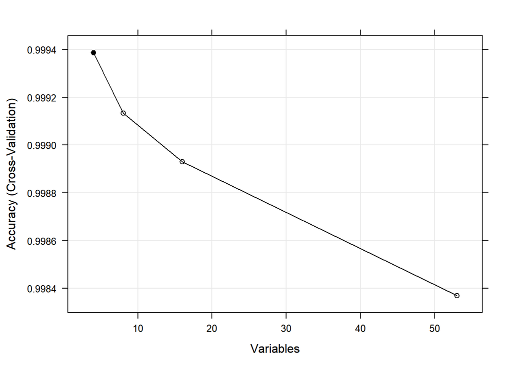

```r
trellis.par.set(caretTheme())
plot(lmProfile, type = c("g", "o"))
```

Creating again classification model, such as Random Forest (RM), and new Gradient Boosting Machine. Both models based on the selected features mentioned above.

```r
predictors <- predictors(lmProfile)
dtrainingCut <- trainingDf[, predictors]

cluster <- parallel::makeCluster(9, outfile = "debug-modelLearning.txt")
doParallel::registerDoParallel(cluster)

trainControl <- trainControl(method = "cv", number = 10, allowParallel = T)

set.seed(62433)
m1 <- train(dtrainingCut, as.factor(trainingPreDf$classe), method = "rf", trControl = trainControl)
set.seed(62433)
m2 <- train(dtrainingCut, as.factor(trainingPreDf$classe), method = "gbm", trControl = trainControl)
parallel::stopCluster(cluster)
foreach::registerDoSEQ() # The only official way to "unregister" a foreach backend is to register the sequential backend:
```

Below is making a prediction using by moth created model and show results.

```r
predict(m1, testingPreDf[, predictors])
```

```
##  [1] B A B A A E D B A A B C B A E E A B B B
## Levels: A B C D E
```

```r
predict(m2, testingPreDf[, predictors])
```

```
##  [1] B A B A A E D B A A B C B A E E A B B B
## Levels: A B C D E
```